# Analysis of A Bike Sharing Company: Cyclistic

Adewale Adio-Yinusa

2023-08-19

# 1 Introduction

## 1.1 Background

Cyclistic offers a bike sharing program that has expanded to a fleet of 5,824 bicycles stationed across 692 stations in Chicago. The company provides an Eco-friendly and convenient means of transportation for both residents and visitors, and aims to increase the subscription rate of its casual riders.

The purpose of this article is to provide valuable insights and recommendations that could help retain and increase Cyclistic’s casual riders.

Note: subscribers and members are used interchangeably throughout this report.

## 1.2 Problem Statement

The company has noticed a lower subscription rate among its casual riders compared to its annual members. In order to understand the factors contributing to this trend, Cyclistic has requested an in depth analysis of its ridership data to proffer solutions on how to retain casual riders.

# 2 Data

## 2.1 Data Description

For this project, historical data was obtained from Cyclistic. An analysis of data from the previous year will be conducted.

## 2.2 Methodology

In this section, all packages that were installed and loaded for this project will be discussed. They are listed below:

- **Tidyverse**: This is a collection of several R packages working together for data importation, manipulation, visualization, and analysis. The packages that would be useful to this project include:
  - **Dplyr**: This package is for data manipulation and provides functions like arrange, filter, mutate, and summarize.
  - **Readr**: This package is for reading flat files like CSV.
  - **Stringr**: This package is for string manipulation, which provides functions that allows for manipulation of text data.
  - **Ggplot2**: This package allows for all visualizations.
- **Lubridate**: This package was installed for ease in working with dates and times, allowing manipulation and formatting.

## 2.3 Data Cleaning

The Tidyverse packages were utilized during data manipulation and wrangling. This section will detail how the data sets were processed prior to analysis.

### 2.3.1 Data Wrangling and Combining into a Single Data Frame

- **Renaming Columns**: Column names in quarters 2, 3, and 4 of 2019 differed from quarter 1 of 2020. To ensure consistency, 2019 column names were renamed to match that of 2020.
- **Converting Datatypes**: The datatype of ride_id and rideable_type were converted to character, to allow datasets to be merged.
- **Merging Data sets**: Data sets for the respective quarters were merged into one dataset.
- **Removing Irrelevant Columns**: Columns that were excluded from 2020 were dropped as they were deemed irrelevant.

### 2.3.2 Prepping Data for Analysis

This section involves renaming columns to ensure uniformity and consistent data types, to merge data sets, to remove irrelevant columns and bad data, and to create new columns for data aggregation.

```r
# Creating New Columns
# New columns **(Day, Month & Year)** were created to enable data aggregation

bike_trips$date <- as.Date(bike_trips$started_at)
bike_trips$month <- format(as.Date(bike_trips$date),"%m")
bike_trips$day <- format(as.Date(bike_trips$date),"%d")
bike_trips$year <- format(as.Date(bike_trips$date),"%Y")
bike_trips$day_of_week <- format(as.Date(bike_trips$date),"%A")

#Creating new column to calculate duration of each ride
bike_trips$ride_length <- difftime(bike_trips$ended_at,bike_trips$started_at)

is.factor(bike_trips$ride_length)
```

```
## [1] FALSE
```

```r
bike_trips$ride_length <- as.numeric(as.character(bike_trips$ride_length))
is.numeric(bike_trips$ride_length)
```

```
## [1] TRUE
```

```r
# Removing Bad Data
bike_trips_v2 <- bike_trips[!(bike_trips$start_station_name == "HQ QR" | bike_trips$ride_length<0),]
```

```r
# Arranging Days of the Week in Order
bike_trips_v2$day_of_week <- ordered(bike_trips_v2$day_of_week, levels=c("Sunday", "Monday", "Tuesday", "Wednesday", "Thursday", "Friday", "Saturday"))
```

# 3 Descriptive Analysis

```
##    Min. 1st Qu.  Median    Mean 3rd Qu.    Max.
##       1     412     712    1479    1289 9387024
```

### 3.0.1 Comparing Members vs Casual Riders

```
## # A tibble: 2 × 2
##   `bike_trips_v2$member_casual` `bike_trips_v2$ride_length`
##   <chr>                                               <dbl>
## 1 casual                                              3553.
## 2 member                                               850.
```

```
## # A tibble: 2 × 2
##   `bike_trips_v2$member_casual` `bike_trips_v2$ride_length`
##   <chr>                                               <dbl>
## 1 casual                                               1546
## 2 member                                                589
```

```
## # A tibble: 2 × 2
##   `bike_trips_v2$member_casual` `bike_trips_v2$ride_length`
##   <chr>                                               <dbl>
## 1 casual                                            9387024
## 2 member                                            9056634
```

```
## # A tibble: 2 × 2
##   `bike_trips_v2$member_casual` `bike_trips_v2$ride_length`
##   <chr>                                               <dbl>
## 1 casual                                                  2
## 2 member                                                  1
```

### 3.0.2 Comparing Average Ride Times by Day for Members vs Casual Rider

```
## # A tibble: 14 × 3
##    `bike_trips_v2$member_casual` bike_trips_v2$day_of_w…¹ bike_trips_v2$ride_l…²
##    <chr>                         <ord>                                     <dbl>
##  1 casual                        Sunday                                    3581.
##  2 member                        Sunday                                     920.
##  3 casual                        Monday                                    3372.
##  4 member                        Monday                                     843.
##  5 casual                        Tuesday                                   3596.
##  6 member                        Tuesday                                    826.
##  7 casual                        Wednesday                                 3719.
##  8 member                        Wednesday                                  824.
##  9 casual                        Thursday                                  3683.
## 10 member                        Thursday                                   824.
## 11 casual                        Friday                                    3774.
## 12 member                        Friday                                     825.
## 13 casual                        Saturday                                  3332.
## 14 member                        Saturday                                   969.
## # ℹ abbreviated names: ¹`bike_trips_v2$day_of_week`,
## #   ²`bike_trips_v2$ride_length`
```

### 3.0.3 Analyzing Ridership Data by Type & Weekday

```
## # A tibble: 14 × 4
##    member_casual weekday number_of_rides average_duration
##    <chr>         <ord>             <int>            <dbl>
##  1 casual        Sun              181293            3581.
##  2 casual        Mon              103296            3372.
##  3 casual        Tue               90510            3596.
##  4 casual        Wed               92457            3719.
##  5 casual        Thu              102679            3683.
##  6 casual        Fri              122404            3774.
##  7 casual        Sat              209543            3332.
##  8 member        Sun              267965             920.
##  9 member        Mon              472196             843.
## 10 member        Tue              508445             826.
## 11 member        Wed              500329             824.
## 12 member        Thu              484177             824.
## 13 member        Fri              452790             825.
## 14 member        Sat              287958             969.
```

# 4 Results and Findings

### 4.0.1 Comparing member vs casual ride counts by weekday

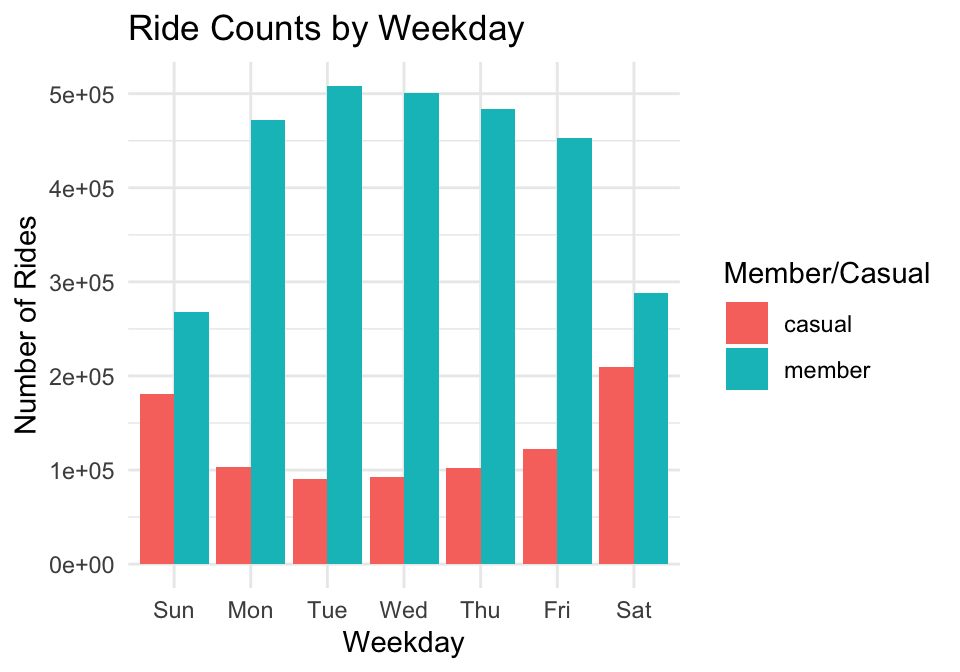

From the graph above, we can draw several conclusions about the behaviors of member and casual riders during the week.

- First, the result shows that on any given day of the week, members made use of the bike services far more than the casual riders.
- However, on the weekends, this gap in the ride counts was much smaller. In other words, the ride counts of the members during the weekdays (Mondays to Fridays) were much more significant than on the weekends (Saturday and Sunday).
- Conversely, for the casual riders, the number of rides on the weekends surpassed that of the weekdays.

These results suggest two things. The first one being that the members use the bike services for their commute to work—hence the consistency in their ride counts during the weekday. The second conclusion is that for the causal riders, the bike services are being used for leisure activities, thus the spike in ride counts on the weekends as opposed to weekdays.

### 4.0.2 Average ride duration by weekday and rider type

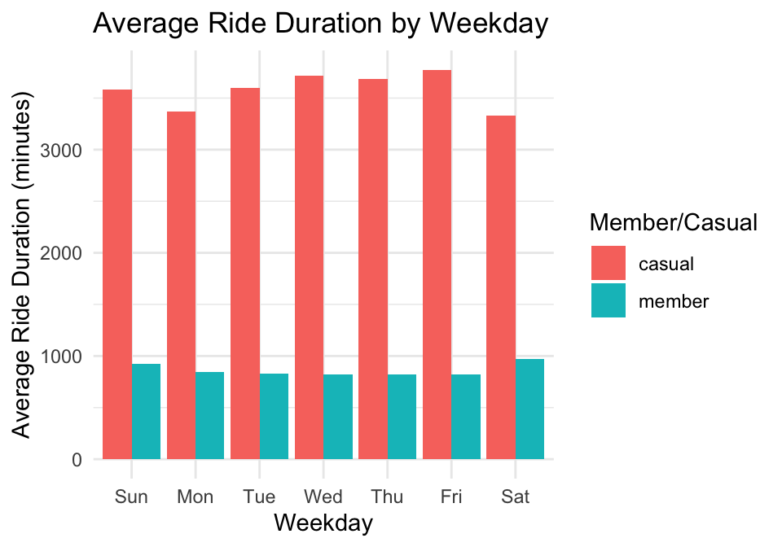

The average ride duration provides an interesting insight into bike usage. From the analysis, we see that casual riders tend to ride the bikes for longer periods of time compared to members/subscribers. This result supports the earlier conclusion which suggested casual riders use the bikes for leisure purposes, as well as for exploring the city while subscribers use the bikes for business purposes.

### 4.0.3 Time series of Average daily Ride Count

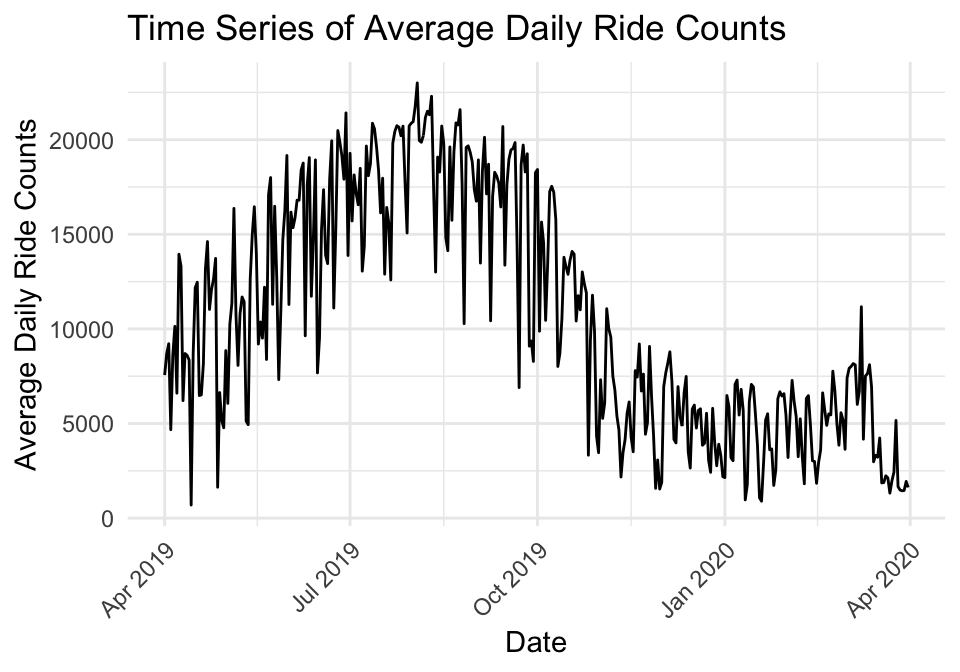

The time series analysis showed usage fluctuation throughout the year. This provides the company the opportunity to anticipate seasonal trends and plan strategic campaigns accordingly.

# 5 Recommendations

Based on the findings from the analysis, I would propose the following recommendations:

- **Seasonal Offers**: From the results, we can see that daily rides are higher during spring and summer months compared to fall and winter months. This is due to the fact that in warmer months, individuals spend more time outside as the temperature is more suitable for outdoor activities. As a result, the focus should be on taking advantage of the opportunity presented during the warmer months. Therefore, I would recommend the company provides offers and promotions during the spring and summer periods to retain more riders.
- **Weekday Offers**: To encourage more casual members, I recommend the company offer discounted subscriptions during the weekdays. This would encourage casual riders to subscribe as they tend to use bike services less during weekdays.
- **Collaborations**: The company should partner with local businesses to provide deals or discounts. This would encourage causal riders to subscribe.
- **Targeted Campaigns**: The marketing team should create ads specifically focused on casual members, informing them of subscription benefits such as discounts, partnerships, and weekend deals as casual riders tend to use bikes more during the weekends.